# Final Project: NBA Shot Analysis

R-Hinos

2023-12-13

[figure not shown]

# 1 Executive Summary

The “NBA Shot Analysis” project aims to revolutionize decision-making in critical moments of NBA games by developing a predictive model for shot outcomes. Utilizing comprehensive data from the 2022-2023 NBA season, we tailored a dataset to contain information crucial for predicting binary shot outcomes. Implications of a model that can predict shot outcomes can give coaches and analytics teams insight to when, where, and with whom a team should be shooting the ball for the best statistical outcome. The ability to increase the chance of success in any given basketball play would have massive financial and non-financial implications including and not limited to player and team bonuses, playoff appearances and wins, and increased fan engagement.

# 2 Motivation

In Game 7 of the 2022 NBA Eastern Conference Finals, the Miami Heat were defeated by the Boston Celtics. Down 2 points with 16 seconds left in the game, the Miami Heat decided not to take a timeout and let Jimmy Butler take a shot from the left-wing of the 3-point line. Butler ended up missing the shot, and the Miami Heat ended up being eliminated from the 2022 NBA Playoffs. There were several implications that arose from Butler’s missed shot. On the financial side, the Miami Heat forewent an NBA Final pool bonus of $3.20-$4.80M, NBA Final’s home game ticket revenue of $42.5-$85.1M, and realized decreased ticket and apparel sales for the 2022-2023 regular season. On the non-financial standpoint, fans were scrutinizing the team, key players left in free agency, and key staff were relieved of their duties. Now imagine this scenario: the Miami Heat called a timeout, drew up a play based on a model’s output that provided data regarding the highest probabilities of making a shot, executed the play, and the shot went in. To make this scenario a reality, we decided to create the NBA Shot Prediction model to equip NBA teams with a tool that can aid in drawing up plays to increase the chance a basket is scored.

# 3 Overview of Dataset

The data set we utilized for this model contains information regarding the game, the player that made the shot, who they were being guarded by, where they took the shot, how much time was left, and much more from the 2022-2023 NBA season. We used the `nba_api` to gather the data from the 2022-2023 Season. Through this we were able to gather all shot information from the Regular Season, as well as personal information regarding each player to make our predictions more accurate. You can find the Python code used to scrape the information here `https://github.com/mrrain02/TO414.git`.

# 4 Model Walkthrough

## 4.1 Load Libraries

```r
library(caret)
library(neuralnet)
library(caret)
library(class)
library(gbm)
library(kernlab)
library(C50)
library(tidyr)
library(dplyr)
library(janitor)
library(randomForest)
library(shiny)
```

## 4.2 Read Data

```r
# Reading in the csv that contains the data set
nba <- read.csv("2022_shot_data.csv", stringsAsFactors = TRUE)
str(nba)
```

```
## 'data.frame':    206687 obs. of  49 variables:
##  $ GRID_TYPE          : Factor w/ 2 levels "","Shot Chart Detail": 2 2 2 2 2 2 2 2 2 2 ...
##  $ GAME_ID            : num  22200008 22200008 22200008 22200008 22200008 ...
##  $ GAME_EVENT_ID      : num  89 113 474 511 542 550 552 556 577 600 ...
##  $ PLAYER_ID          : int  1630173 1630173 1630173 1630173 1630173 1630173 1630173 1630173 1630173 1630173 ...
##  $ PLAYER_NAME        : Factor w/ 435 levels "","A.J. Lawson",..: 355 355 355 355 355 355 355 355 355 355 ...
##  $ TEAM_ID_x          : num  1.61e+09 1.61e+09 1.61e+09 1.61e+09 1.61e+09 ...
##  $ TEAM_NAME_x        : Factor w/ 31 levels "","Atlanta Hawks",..: 29 29 29 29 29 29 29 29 29 29 ...
##  $ PERIOD             : num  1 1 3 3 4 4 4 4 4 4 ...
##  $ MINUTES_REMAINING  : num  4 3 3 0 10 9 9 9 7 5 ...
##  $ SECONDS_REMAINING  : num  50 59 8 41 18 40 34 7 9 11 ...
##  $ EVENT_TYPE         : Factor w/ 3 levels "","Made Shot",..: 3 3 3 2 2 3 2 3 3 3 ...
##  $ ACTION_TYPE        : Factor w/ 49 levels "","Alley Oop Dunk Shot",..: 24 36 20 5 24 24 6 41 25 42 ...
##  $ SHOT_TYPE          : Factor w/ 3 levels "","2PT Field Goal",..: 3 2 2 2 3 3 2 3 2 2 ...
##  $ SHOT_ZONE_BASIC    : Factor w/ 8 levels "","Above the Break 3",..: 2 7 4 7 2 2 7 8 4 7 ...
```

[output cut: 35 more lines]

```r
summary(nba)
```

```
##              GRID_TYPE         GAME_ID         GAME_EVENT_ID
##                   :    97   Min.   :22200001   Min.   :  4.0
##  Shot Chart Detail:206590   1st Qu.:22200312   1st Qu.:153.0
##                             Median :22200622   Median :323.0
##                             Mean   :22200619   Mean   :323.8
##                             3rd Qu.:22200926   3rd Qu.:488.0
##                             Max.   :22201230   Max.   :895.0
##                             NA's   :97         NA's   :97
##    PLAYER_ID                 PLAYER_NAME       TEAM_ID_x
##  Min.   :   2544   Jayson Tatum    :  1559   Min.   :1.611e+09
##  1st Qu.: 203967   Anthony Edwards :  1541   1st Qu.:1.611e+09
##  Median :1628963   Luka Doncic     :  1449   Median :1.611e+09
##  Mean   :1239482   Julius Randle   :  1432   Mean   :1.611e+09
##  3rd Qu.:1630168   Donovan Mitchell:  1402   3rd Qu.:1.611e+09
##  Max.   :1641936   Trae Young      :  1390   Max.   :1.611e+09
##                    (Other)         :197914   NA's   :97
##                 TEAM_NAME_x         PERIOD      MINUTES_REMAINING
##  Memphis Grizzlies    :  7468   Min.   :1.000   Min.   : 0.000
##  Oklahoma City Thunder:  7432   1st Qu.:1.000   1st Qu.: 2.000
##  Atlanta Hawks        :  7422   Median :2.000   Median : 5.000
##  New York Knicks      :  7324   Mean   :2.474   Mean   : 5.407
##  Charlotte Hornets    :  7277   3rd Qu.:3.000   3rd Qu.: 8.000
##  Indiana Pacers       :  7241   Max.   :6.000   Max.   :12.000
##  (Other)              :162523   NA's   :97      NA's   :97
##  SECONDS_REMAINING       EVENT_TYPE                         ACTION_TYPE
##  Min.   : 0.00                :    97   Jump Shot                 :60586
##  1st Qu.:14.00     Made Shot  : 98455   Pullup Jump shot          :25892
##  Median :29.00     Missed Shot:108135   Driving Layup Shot        :18239
##  Mean   :28.83                          Driving Floating Jump Shot:10700
##  3rd Qu.:44.00                          Step Back Jump shot       :10047
##  Max.   :59.00                          Running Layup Shot        : 6338
##  NA's   :97                             (Other)                   :74885
##           SHOT_TYPE                   SHOT_ZONE_BASIC
##                :    97   Restricted Area      :61744
##  2PT Field Goal:126631   Above the Break 3    :59689
##  3PT Field Goal: 79959   In The Paint (Non-RA):40411
##                          Mid-Range            :24597
##                          Left Corner 3        :10398
##                          Right Corner 3       : 9373
##                          (Other)              :  475
```

[output cut: 57 more lines]

```
##  Min.   : 1.00   Min.   :1     Min.   :2003   Min.   :2023   Min.   : 0.00
##  1st Qu.: 6.00   1st Qu.:1     1st Qu.:2014   1st Qu.:2023   1st Qu.: 7.90
##  Median :14.00   Median :1     Median :2018   Median :2023   Median :13.00
##  Mean   :17.63   Mean   :1     Mean   :2017   Mean   :2023   Mean   :14.19
##  3rd Qu.:27.00   3rd Qu.:1     3rd Qu.:2020   3rd Qu.:2023   3rd Qu.:20.10
##  Max.   :60.00   Max.   :1     Max.   :2023   Max.   :2023   Max.   :31.90
##  NA's   :20495   NA's   :50                                  NA's   :9304
##       REB              AST         STATS_TIMEFRAME
##  Min.   : 0.000   Min.   : 0.000   Season:206687
##  1st Qu.: 2.900   1st Qu.: 1.300
##  Median : 4.200   Median : 2.900
##  Mean   : 4.707   Mean   : 3.196
##  3rd Qu.: 6.000   3rd Qu.: 4.700
##  Max.   :13.800   Max.   :11.600
##  NA's   :9304     NA's   :9304
```

```r
# Randomize the rows so all player shots are not the same
set.seed(12345)
nba <- nba[sample(nrow(nba)),]

# Since there are over 200,000 Data points, need to take smaller randomized selection
set.seed(12345)
sample_size <- 0.1
nba <- nba[sample(1:nrow(nba), sample_size*nrow(nba)), ]
```

## 4.3 Cleaning Dataset

### 4.3.1 Methodology and Importance

Data cleaning is a crucial step in preparing our dataset for effective modeling. This process involves removing irrelevant data, handling missing values, and transforming variables to a format suitable for analysis. By cleaning the data, we aim to improve the accuracy and reliability of our predictive models, ultimately leading to more precise and actionable insights.

### 4.3.3 Impact on Model Performance

- **Enhanced Model Accuracy**: Clean data without irrelevant or redundant information improves the accuracy of our models.
- **Reduced Overfitting**: By removing unnecessary predictors, we reduce the risk of overfitting our models to noise.
- **Improved Interpretability**: Clean and well-structured data make the models’ outputs more interpretable and actionable.

```r
# Remove Unnecessary Columns
nba$GRID_TYPE <- NULL
nba$GAME_ID <- NULL
nba$GAME_EVENT_ID <- NULL
nba$PLAYER_ID <- NULL
nba$PLAYER_NAME <- NULL
nba$TEAM_ID_x <- NULL
nba$EVENT_TYPE <- NULL
nba$SHOT_ATTEMPTED_FLAG <- NULL
nba$GAME_DATE <- NULL
nba$PLAYER_LAST_NAME <- NULL
nba$PLAYER_FIRST_NAME <- NULL
nba$PLAYER_SLUG <- NULL
nba$TEAM_ID_y <- NULL
nba$TEAM_SLUG <- NULL
nba$IS_DEFUNCT <- NULL
nba$TEAM_CITY <- NULL
nba$TEAM_NAME_x <- NULL
nba$TEAM_NAME_y <- NULL
nba$TEAM_ABBREVIATION <- NULL
nba$DRAFT_YEAR <- NULL
nba$DRAFT_NUMBER <- NULL
nba$STATS_TIMEFRAME <- NULL
nba$ROSTER_STATUS <- NULL

# Take Top 5 Colleges, Factorize Everything Else
nba$COLLEGE <- as.character(nba$COLLEGE)
nba$COLLEGE <- ifelse(!(nba$COLLEGE == "Kentucky" | nba$COLLEGE == "Duke" | nba$COLLEGE == "UCLA" |
nba$COLLEGE == "Arizona" | nba$COLLEGE == "Michigan"), "Other", nba$COLLEGE)
nba$COLLEGE <- as.factor(nba$COLLEGE)

# Take Top 3 Countries, Factorize Everything Else
nba$COUNTRY <- as.character(nba$COUNTRY)
nba$COUNTRY <- ifelse(!(nba$COUNTRY == "USA" | nba$COUNTRY == "Canada" | nba$COUNTRY == "Australia"), "Other", nba$COLLEGE)
nba$COUNTRY <- as.factor(nba$COUNTRY)

# Take Top 5 Heights, Factorize Everything Else
nba$HEIGHT <- as.character(nba$HEIGHT)
nba$HEIGHT <- ifelse(!(nba$HEIGHT == "6-5" | nba$HEIGHT == "6-4" | nba$HEIGHT == "6-8" |
nba$HEIGHT == "6-6" | nba$HEIGHT == "6-7"), "Other", nba$HEIGHT)
nba$HEIGHT <- as.factor(nba$HEIGHT)


# Action Type
nba$ACTION_TYPE <- as.character(nba$ACTION_TYPE)
nba$ACTION_TYPE <- ifelse(!(nba$ACTION_TYPE == "Jump Shot" | nba$ACTION_TYPE == "Pullup Jump shot" | nba$ACTION_TYPE == "Driving Layup Shot" |
nba$ACTION_TYPE == "Driving Floating Jump Shot" | nba$ACTION_TYPE == "Layup Shot" | nba$ACTION_TYPE == "Running Layup Shot" | nba$ACTION_TYPE == "Step Back Jump shot" | nba$ACTION_TYPE == "Driving Finger Roll Layup Shot" | nba$ACTION_TYPE == "Cutting Layup Shot" | nba$ACTION_TYPE == "Tip Layup Shot"), "Other", nba$ACTION_TYPE)
nba$ACTION_TYPE <- as.factor(nba$ACTION_TYPE)

# Some Players are Undrafted, so Undraft Round and Number Will be Set to "0" to represent that (Make them factors as well)
nba$DRAFT_ROUND[is.na(nba$DRAFT_ROUND)] <- "un_draft"
nba$DRAFT_ROUND <- as.factor(nba$DRAFT_ROUND)

# PTS, REB, AST have some NA Values. We Replace NA values with the median in each column
nba$PTS[is.na(nba$PTS)] <- median(nba$PTS, na.rm = TRUE)
nba$REB[is.na(nba$REB)] <- median(nba$REB, na.rm = TRUE)
nba$AST[is.na(nba$AST)] <- median(nba$AST, na.rm = TRUE)


# Create New Column that Shows Total Number of Years in NBA
nba$YEARS_NBA <- (nba$TO_YEAR - nba$FROM_YEAR) + 1
nba$FROM_YEAR <- NULL
nba$TO_YEAR <- NULL

nba$SHOT_MADE_FLAG <- as.factor(nba$SHOT_MADE_FLAG)

# There are some NA's (less than 90). We are just going to remove these rows
nba <- na.omit(nba)

colSums(is.na(nba))
```

```
##            PERIOD MINUTES_REMAINING SECONDS_REMAINING       ACTION_TYPE
##                 0                 0                 0                 0
##         SHOT_TYPE   SHOT_ZONE_BASIC    SHOT_ZONE_AREA   SHOT_ZONE_RANGE
##                 0                 0                 0                 0
##     SHOT_DISTANCE             LOC_X             LOC_Y    SHOT_MADE_FLAG
##                 0                 0                 0                 0
##               HTM               VTM     JERSEY_NUMBER          POSITION
##                 0                 0                 0                 0
##            HEIGHT            WEIGHT           COLLEGE           COUNTRY
##                 0                 0                 0                 0
##       DRAFT_ROUND               PTS               REB               AST
##                 0                 0                 0                 0
##         YEARS_NBA
##                 0
```

```r
# Some Factor Levels have "" from the Empty Strings in the Original Dataset. Need to remove these
nba$SHOT_TYPE <- droplevels(nba$SHOT_TYPE, exclude = "")
nba$SHOT_ZONE_BASIC <- droplevels(nba$SHOT_ZONE_BASIC, exclude = "")
nba$SHOT_ZONE_AREA <- droplevels(nba$SHOT_ZONE_AREA, exclude = "")
nba$SHOT_ZONE_RANGE <- droplevels(nba$SHOT_ZONE_RANGE, exclude = "")
nba$HTM <- droplevels(nba$HTM, exclude = "")
nba$VTM <- droplevels(nba$VTM, exclude = "")
str(nba)
```

```
## 'data.frame':    20651 obs. of  25 variables:
##  $ PERIOD           : num  3 1 4 4 3 2 3 1 1 1 ...
##  $ MINUTES_REMAINING: num  3 11 10 1 5 8 11 7 6 10 ...
##  $ SECONDS_REMAINING: num  29 2 2 1 21 29 42 8 1 47 ...
##  $ ACTION_TYPE      : Factor w/ 11 levels "Cutting Layup Shot",..: 5 5 4 5 7 8 8 7 7 8 ...
##  $ SHOT_TYPE        : Factor w/ 2 levels "2PT Field Goal",..: 2 1 1 2 1 2 2 1 1 1 ...
##  $ SHOT_ZONE_BASIC  : Factor w/ 7 levels "Above the Break 3",..: 1 5 6 7 5 1 1 6 3 5 ...
##  $ SHOT_ZONE_AREA   : Factor w/ 6 levels "Back Court(BC)",..: 5 5 2 6 4 2 3 2 2 2 ...
##  $ SHOT_ZONE_RANGE  : Factor w/ 5 levels "16-24 ft.","24+ ft.",..: 2 1 5 2 1 2 2 5 5 3 ...
##  $ SHOT_DISTANCE    : num  26 18 3 22 16 31 24 1 6 15 ...
##  $ LOC_X            : num  168 126 0 222 -159 -7 -85 -4 -31 4 ...
##  $ LOC_Y            : num  206 137 36 -4 18 314 231 10 52 150 ...
##  $ SHOT_MADE_FLAG   : Factor w/ 2 levels "0","1": 1 2 1 1 1 1 1 2 2 2 ...
##  $ HTM              : Factor w/ 30 levels "ATL","BKN","BOS",..: 21 27 8 30 28 8 2 18 18 25 ...
##  $ VTM              : Factor w/ 30 levels "ATL","BKN","BOS",..: 24 19 16 1 16 10 25 12 19 18 ...
##  $ JERSEY_NUMBER    : num  1 17 5 5 13 30 11 27 17 5 ...
##  $ POSITION         : Factor w/ 7 levels "C","C-F","F",..: 6 1 6 6 2 6 6 1 1 6 ...
##  $ HEIGHT           : Factor w/ 6 levels "6-4","6-5","6-6",..: 3 6 6 6 6 6 6 6 6 1 ...
##  $ WEIGHT           : int  206 265 169 183 255 185 195 258 265 225 ...
##  $ COLLEGE          : Factor w/ 6 levels "Arizona","Duke",..: 3 5 5 5 3 5 2 5 5 5 ...
##  $ COUNTRY          : Factor w/ 7 levels "1","2","3","4",..: 3 7 5 5 3 5 2 7 7 5 ...
##  $ DRAFT_ROUND      : Factor w/ 4 levels "0","1","2","un_draft": 2 2 2 3 2 2 2 2 2 2 ...
##  $ PTS              : num  28.8 13.6 11.8 13 22.8 30.3 23.9 11.7 13.6 26 ...
##  $ REB              : num  5.6 8.4 1.6 4.2 10.2 4.8 3.9 12.3 8.4 5.6 ...
##  $ AST              : num  9.8 2.2 2.9 2.9 3.9 3.8 6.1 1.3 2.2 5.1 ...
##  $ YEARS_NBA        : num  9 12 3 7 7 15 13 11 12 4 ...
##  - attr(*, "na.action")= 'omit' Named int [1:17] 102 965 4490 5150 7496 7711 8402 8786 8900 9748 ...
##   ..- attr(*, "names")= chr [1:17] "182850" "185431" "181597" "151015" ...
```

```r
summary(nba)
```

```
##      PERIOD      MINUTES_REMAINING SECONDS_REMAINING
##  Min.   :1.000   Min.   : 0.000    Min.   : 0.00
##  1st Qu.:1.000   1st Qu.: 2.000    1st Qu.:14.00
##  Median :2.000   Median : 5.000    Median :29.00
##  Mean   :2.479   Mean   : 5.409    Mean   :28.75
##  3rd Qu.:3.000   3rd Qu.: 8.000    3rd Qu.:44.00
##  Max.   :6.000   Max.   :11.000    Max.   :59.00
##
##                      ACTION_TYPE            SHOT_TYPE
##  Jump Shot                 :6161   2PT Field Goal:12493
##  Other                     :5363   3PT Field Goal: 8158
##  Pullup Jump shot          :2552
##  Driving Layup Shot        :1776
##  Driving Floating Jump Shot:1064
##  Step Back Jump shot       :1060
##  (Other)                   :2675
##               SHOT_ZONE_BASIC               SHOT_ZONE_AREA
##  Above the Break 3    :6148   Back Court(BC)       :   39
##  Backcourt            :  36   Center(C)            :11670
##  In The Paint (Non-RA):3940   Left Side Center(LC) : 2653
##  Left Corner 3        :1027   Left Side(L)         : 1863
##  Mid-Range            :2467   Right Side Center(RC): 2632
##  Restricted Area      :6097   Right Side(R)        : 1794
##  Right Corner 3       : 936
##         SHOT_ZONE_RANGE SHOT_DISTANCE       LOC_X              LOC_Y
##  16-24 ft.      :1309   Min.   : 0.00   Min.   :-249.000   Min.   :-52.00
##  24+ ft.        :8108   1st Qu.: 3.00   1st Qu.: -48.000   1st Qu.: 14.00
##  8-16 ft.       :2795   Median :13.00   Median :   0.000   Median : 57.00
##  Back Court Shot:  39   Mean   :13.65   Mean   :  -1.479   Mean   : 96.37
##  Less Than 8 ft.:8400   3rd Qu.:25.00   3rd Qu.:  45.000   3rd Qu.:183.00
##                         Max.   :80.00   Max.   : 250.000   Max.   :800.00
##
##  SHOT_MADE_FLAG      HTM             VTM        JERSEY_NUMBER   POSITION
##  0:10741        ATL    :  722   IND    :  748   Min.   : 0.00   C  :1450
##  1: 9910        HOU    :  721   SAS    :  736   1st Qu.: 5.00   C-F: 767
##                 CHA    :  718   LAL    :  725   Median :11.00   F  :5284
##                 SAS    :  718   CHA    :  722   Mean   :15.29   F-C:1434
##                 MIL    :  716   BOS    :  709   3rd Qu.:23.00   F-G:1165
##                 ORL    :  713   MEM    :  706   Max.   :99.00   G  :8750
##                 (Other):16343   (Other):16305                   G-F:1801
##    HEIGHT         WEIGHT        COLLEGE       COUNTRY        DRAFT_ROUND
##  6-4  :2226   Min.   :160   Arizona :  537   1    :  303   0       :   60
##  6-5  :2899   1st Qu.:198   Duke    : 1275   2    : 1275   1       :15224
##  6-6  :2152   Median :215   Kentucky: 1793   3    : 1755   2       : 3320
##  6-7  :2017   Mean   :216   Michigan:  546   4    :  379   un_draft: 2047
##  6-8  :2180   3rd Qu.:230   Other   :15928   5    :12964
##  Other:9177   Max.   :290   UCLA    :  572   6    :  572
##                                              Other: 3403
##       PTS             REB              AST           YEARS_NBA
##  Min.   : 0.00   Min.   : 0.000   Min.   : 0.000   Min.   : 2.000
##  1st Qu.: 8.50   1st Qu.: 2.900   1st Qu.: 1.400   1st Qu.: 4.000
##  Median :13.00   Median : 4.200   Median : 2.900   Median : 6.000
##  Mean   :14.15   Mean   : 4.671   Mean   : 3.179   Mean   : 7.228
##  3rd Qu.:19.60   3rd Qu.: 5.800   3rd Qu.: 4.500   3rd Qu.:10.000
##  Max.   :31.90   Max.   :13.800   Max.   :11.600   Max.   :21.000
##
```

## 4.4 Pre Process Data

### 4.4.1 Objective of Pre-Processing

Data pre-processing is an essential stage in preparing our dataset for predictive modeling. This step involves transforming raw data into a format that is more suitable for analysis, enhancing the performance and accuracy of our predictive models.

### 4.4.2 Pre-Processing Steps

1. **Converting Categorical Variables to Dummy Variables**:
   - We use `model.matrix` to convert categorical variables in our dataset (`nba`) into dummy variables. This transformation is crucial because models like K-Nearest Neighbors (KNN) require numerical input.
   - The syntax `model.matrix(~.-1, nba)` creates dummy variables for all categorical variables in `nba`, excluding the intercept term (indicated by `-1`).
2. **Standardizing Names**:
   - After transformation, we standardize the column names using `clean_names` from the `janitor` package. This step ensures that our column names are consistent and readable, which is vital for later stages of analysis and modeling.
3. **Normalizing the Data**:
   - We define a `normalize` function that scales numeric values to a range of 0 to 1. This normalization is done by subtracting the minimum value of each column and dividing by the range of the column.
   - We apply this normalization to all columns in `nbamm` to prepare the data for models like KNN and ANN, which are sensitive to the scale of input data.

### 4.4.3 Importance of Pre-Processing

- **Improving Model Performance**: Normalizing and converting data to a suitable format helps improve the performance of machine learning models, especially those sensitive to the scale of data, such as KNN and ANN.
- **Ensuring Compatibility**: Converting categorical data to dummy variables ensures compatibility with a wide range of machine learning algorithms that require numerical input.
- **Data Standardization**: Normalizing data brings all variables to the same scale, reducing bias towards variables with larger ranges.

```r
# Using model.matrix to convert all the factors to dummy variables
# We are converting all of the factors into dummy variables as the input into knn has to be numeric

nbamm <- as.data.frame(model.matrix(~.-1,nba))
nbamm <- clean_names(nbamm)
str(nbamm)
```

```
## 'data.frame':    20651 obs. of  123 variables:
##  $ period                                    : num  3 1 4 4 3 2 3 1 1 1 ...
##  $ minutes_remaining                         : num  3 11 10 1 5 8 11 7 6 10 ...
##  $ seconds_remaining                         : num  29 2 2 1 21 29 42 8 1 47 ...
##  $ action_type_cutting_layup_shot            : num  0 0 0 0 0 0 0 0 0 0 ...
##  $ action_type_driving_finger_roll_layup_shot: num  0 0 0 0 0 0 0 0 0 0 ...
##  $ action_type_driving_floating_jump_shot    : num  0 0 0 0 0 0 0 0 0 0 ...
##  $ action_type_driving_layup_shot            : num  0 0 1 0 0 0 0 0 0 0 ...
##  $ action_type_jump_shot                     : num  1 1 0 1 0 0 0 0 0 0 ...
##  $ action_type_layup_shot                    : num  0 0 0 0 0 0 0 0 0 0 ...
##  $ action_type_other                         : num  0 0 0 0 1 0 0 1 1 0 ...
##  $ action_type_pullup_jump_shot              : num  0 0 0 0 0 1 1 0 0 1 ...
##  $ action_type_running_layup_shot            : num  0 0 0 0 0 0 0 0 0 0 ...
##  $ action_type_step_back_jump_shot           : num  0 0 0 0 0 0 0 0 0 0 ...
##  $ action_type_tip_layup_shot                : num  0 0 0 0 0 0 0 0 0 0 ...
```

[output cut: 86 more lines]

```r
#Normalize the data
normalize <- function(x) {
  return ((x - min(x)) / (max(x) - min(x)))
}

# We are going to normalize everything for KNN and ANN
nba_norm <- as.data.frame(lapply(nbamm, normalize))
summary(nba_norm)
```

```
##      period       minutes_remaining seconds_remaining
##  Min.   :0.0000   Min.   :0.0000    Min.   :0.0000
##  1st Qu.:0.0000   1st Qu.:0.1818    1st Qu.:0.2373
##  Median :0.2000   Median :0.4545    Median :0.4915
##  Mean   :0.2957   Mean   :0.4918    Mean   :0.4872
##  3rd Qu.:0.4000   3rd Qu.:0.7273    3rd Qu.:0.7458
##  Max.   :1.0000   Max.   :1.0000    Max.   :1.0000
##  action_type_cutting_layup_shot action_type_driving_finger_roll_layup_shot
##  Min.   :0.00000                Min.   :0.00000
##  1st Qu.:0.00000                1st Qu.:0.00000
##  Median :0.00000                Median :0.00000
##  Mean   :0.02528                Mean   :0.02688
##  3rd Qu.:0.00000                3rd Qu.:0.00000
##  Max.   :1.00000                Max.   :1.00000
##  action_type_driving_floating_jump_shot action_type_driving_layup_shot
##  Min.   :0.00000                        Min.   :0.000
##  1st Qu.:0.00000                        1st Qu.:0.000
##  Median :0.00000                        Median :0.000
##  Mean   :0.05152                        Mean   :0.086
##  3rd Qu.:0.00000                        3rd Qu.:0.000
##  Max.   :1.00000                        Max.   :1.000
##  action_type_jump_shot action_type_layup_shot action_type_other
##  Min.   :0.0000        Min.   :0.00000        Min.   :0.0000
##  1st Qu.:0.0000        1st Qu.:0.00000        1st Qu.:0.0000
##  Median :0.0000        Median :0.00000        Median :0.0000
##  Mean   :0.2983        Mean   :0.02552        Mean   :0.2597
##  3rd Qu.:1.0000        3rd Qu.:0.00000        3rd Qu.:1.0000
##  Max.   :1.0000        Max.   :1.00000        Max.   :1.0000
##  action_type_pullup_jump_shot action_type_running_layup_shot
##  Min.   :0.0000               Min.   :0.00000
##  1st Qu.:0.0000               1st Qu.:0.00000
##  Median :0.0000               Median :0.00000
##  Mean   :0.1236               Mean   :0.03172
##  3rd Qu.:0.0000               3rd Qu.:0.00000
##  Max.   :1.0000               Max.   :1.00000
##  action_type_step_back_jump_shot action_type_tip_layup_shot
##  Min.   :0.00000                 Min.   :0.00000
##  1st Qu.:0.00000                 1st Qu.:0.00000
##  Median :0.00000                 Median :0.00000
##  Mean   :0.05133                 Mean   :0.02014
```

[output cut: 204 more lines]

```
##  Max.   :1.00000   Max.   :1.0000   Max.   :1.0000   Max.   :1.0000
##   draft_round1     draft_round2    draft_roun_dun_draft      pts
##  Min.   :0.0000   Min.   :0.0000   Min.   :0.00000      Min.   :0.0000
##  1st Qu.:0.0000   1st Qu.:0.0000   1st Qu.:0.00000      1st Qu.:0.2665
##  Median :1.0000   Median :0.0000   Median :0.00000      Median :0.4075
##  Mean   :0.7372   Mean   :0.1608   Mean   :0.09912      Mean   :0.4437
##  3rd Qu.:1.0000   3rd Qu.:0.0000   3rd Qu.:0.00000      3rd Qu.:0.6144
##  Max.   :1.0000   Max.   :1.0000   Max.   :1.00000      Max.   :1.0000
##       reb              ast           years_nba
##  Min.   :0.0000   Min.   :0.0000   Min.   :0.0000
##  1st Qu.:0.2101   1st Qu.:0.1207   1st Qu.:0.1053
##  Median :0.3043   Median :0.2500   Median :0.2105
##  Mean   :0.3385   Mean   :0.2741   Mean   :0.2751
##  3rd Qu.:0.4203   3rd Qu.:0.3879   3rd Qu.:0.4211
##  Max.   :1.0000   Max.   :1.0000   Max.   :1.0000
```

## 4.5 Splitting Train and Test

### 4.5.1 Purpose of Splitting Data

Splitting the dataset into training and testing sets is a fundamental step in the process of building and validating predictive models. The training set is used to train the model, allowing it to learn the patterns in the data. The testing set, which the model has not seen during training, is used to evaluate its performance. This approach helps in assessing how well the model generalizes to new, unseen data.

### 4.5.2 Methodology

1. **Setting a Seed for Reproducibility**: We begin by setting a seed (`set.seed(12345)`) to ensure that our results are reproducible. This means that every time the code is run, it will generate the same random split of data.
2. **Creating Train and Test Indices**: We randomly sample 70% of the data indices to create our training set, ensuring that a majority of the data is used for training the model, while leaving enough data for an effective test.
3. **Splitting for Different Models**:
   - **Logistic Regression**: The dataset (`nba`) is split into `nba_log_train` and `nba_log_test` for training and testing the logistic regression model.
   - **Artificial Neural Network (ANN)**: A normalized version of the dataset (`nba_norm`) is used to split into training (`nba_ann_train`) and testing (`nba_ann_test`) sets for the ANN model.
   - **Support Vector Machine (SVM)**: Another transformed version of the dataset (`nbamm`) is split for training (`nba_svm_train`) and testing (`nba_svm_test`) the SVM model.
4. **Separating Predictors and Labels**:
   - We create separate datasets for predictors (`nba_train`, `nba_test`) and labels (`nba_train_labels`, `nba_test_labels`). This is essential for supervised learning where the model needs to learn to predict the labels from the predictors.

### 4.5.3 Importance of This Approach

- **Avoiding Overfitting**: By testing the model on data it hasn’t seen before (test set), we can gauge its ability to generalize and avoid overfitting to the training data.
- **Model Validation**: The test set acts as a proxy for new data, helping validate the model’s performance in real-world scenarios.
- **Balanced Representation**: Using 70% of the data for training strikes a balance, allowing the model to learn effectively while having enough data to test its predictions.

```r
set.seed(12345)
train_set <- sample(1:nrow(nba), 0.7*nrow(nba))

# Split for Logistical Regression
nba_log_train <- nba[train_set, ]
nba_log_test <- nba[-train_set, ]

# Split for ANN
nba_ann_train <- nba_norm[train_set, ]
nba_ann_test <- nba_norm[-train_set, ]


# Split for SVM
nba_svm_train <- nbamm[train_set, ]
nba_svm_test <- nbamm[-train_set, ]

#Create a train set and test set with separate x and y cols
#First the predictors - all columns except the yyes column
nba_train <- nba_norm[train_set, -match("shot_made_flag1",names(nba_norm))]
nba_test <- nba_norm[-train_set, -match("shot_made_flag1",names(nba_norm))]

#Now the response (aka Labels) - only the yyes column
nba_train_labels <- nba_norm[train_set, "shot_made_flag1"]
nba_test_labels <- nba_norm[-train_set, "shot_made_flag1"]
```

## 4.6 Creating Models

### 4.6.1 Overview

In our NBA Shot Analysis project, we have employed a range of machine learning models. Each model has its unique strengths and caters to different aspects of prediction, enhancing the robustness of our analysis. Below, we outline the models we created and the rationale behind choosing them.

### 4.6.3 Importance of Model Diversity

- **Comprehensive Analysis**: Using different models allows us to capture various aspects of the data, making our analysis more comprehensive.
- **Model Validation**: Comparing predictions from multiple models helps in validating the results and ensures that our conclusions are robust.

### 4.6.4 Conclusion

The diverse set of models created in this project allows for a multi-faceted analysis of NBA shot data. Each model contributes uniquely to our understanding of what factors influence shot success, thereby enhancing the overall predictive power and reliability of our analysis.

## 4.7 Models

### 4.7.1 Logistical Regression

```r
NbaModel=glm(SHOT_MADE_FLAG ~., data=nba_log_train,family="binomial")


Nba_StepBase = glm(SHOT_MADE_FLAG ~ PERIOD + SECONDS_REMAINING + ACTION_TYPE + SHOT_TYPE +
    SHOT_ZONE_BASIC + SHOT_ZONE_RANGE + HTM + WEIGHT + DRAFT_ROUND +
    YEARS_NBA + log1p(SHOT_DISTANCE) + sqrt(PTS) + sqrt(REB) +
    sqrt(YEARS_NBA) + SHOT_TYPE:SHOT_ZONE_BASIC, data=nba_log_train,family="binomial")

# Use the logistic regression model 'NbaModel' to generate predictions on the test dataset

testpred1 <- predict(Nba_StepBase, nba_log_test, type = "response")
# Convert the predicted probabilities into binary outcomes: 1 if probability >= 0.38, otherwise 0
binpred1 <- ifelse(testpred1 >=.50, 1, 0)
# Generate a confusion matrix to evaluate the performance of t-he predictions against the actual test labels

confusionMatrix(as.factor(binpred1), as.factor(nba_log_test$SHOT_MADE_FLAG), positive = "1")
```

```
## Confusion Matrix and Statistics
##
##           Reference
## Prediction    0    1
##          0 2493 1538
##          1  701 1464
##
##                Accuracy : 0.6386
##                  95% CI : (0.6265, 0.6506)
##     No Information Rate : 0.5155
##     P-Value [Acc > NIR] : < 2.2e-16
##
##                   Kappa : 0.2705
##
##  Mcnemar's Test P-Value : < 2.2e-16
##
##             Sensitivity : 0.4877
##             Specificity : 0.7805
##          Pos Pred Value : 0.6762
##          Neg Pred Value : 0.6185
##              Prevalence : 0.4845
##          Detection Rate : 0.2363
##    Detection Prevalence : 0.3494
##       Balanced Accuracy : 0.6341
##
##        'Positive' Class : 1
##
```

### 4.7.2 Boosting

```r
# set.seed(12345)
# boost <- gbm(shot_made_flag1 ~ ., data = nba_ann_train,
#              distribution = "gaussian",
#              n.trees = 1000, shrinkage = 0.01,
#              interaction.depth = 4,
#              bag.fraction = 0.7,
#              n.minobsinnode = 5)
# saveRDS(boost, "boost.rds")
# Load the model
boost <- readRDS("boost.rds")


boost_prediction <- predict(boost, nba_ann_test)
```

```
## Using 1000 trees...
```

```r
# Display a summary of the ANN model's predictions
summary(boost_prediction)
```

```
##    Min. 1st Qu.  Median    Mean 3rd Qu.    Max.
## 0.06427 0.37515 0.43585 0.48400 0.55129 0.92091
```

```r
# Convert the predicted probabilities from the ANN model into binary outcomes: 1 if probability > 0.35, otherwise 0
binary_ann <- ifelse(boost_prediction > .48, 1, 0)

# Generate a confusion matrix to evaluate the performance of the binary predictions against the actual test labels
confusionMatrix(as.factor(binary_ann), as.factor(nba_test_labels), positive = "1")
```

```
## Confusion Matrix and Statistics
##
##           Reference
## Prediction    0    1
##          0 2419 1495
##          1  775 1507
##
##                Accuracy : 0.6336
##                  95% CI : (0.6215, 0.6456)
##     No Information Rate : 0.5155
##     P-Value [Acc > NIR] : < 2.2e-16
##
##                   Kappa : 0.2612
##
##  Mcnemar's Test P-Value : < 2.2e-16
##
##             Sensitivity : 0.5020
##             Specificity : 0.7574
##          Pos Pred Value : 0.6604
##          Neg Pred Value : 0.6180
##              Prevalence : 0.4845
##          Detection Rate : 0.2432
##    Detection Prevalence : 0.3683
##       Balanced Accuracy : 0.6297
##
##        'Positive' Class : 1
##
```

### 4.7.3 KNN Model

```r
set.seed(12345)
# knnpred <- knn(nba_train, nba_test, nba_train_labels, k = 150, prob=FALSE)

# (Comment) Save the model to a file
# saveRDS(knnpred, "knn_model_5.rds")
# Load the model
knn_model <- readRDS("knn_model_5.rds")

# Generate a confusion matrix using the 'caret' library to evaluate the performance of the KNN predictions ('knnpred') against the actual test labels ('tele_test_labels'). The 'positive' argument specifies that the positive class label is "1".
confusionMatrix(as.factor(knn_model), as.factor(nba_test_labels), positive="1")
```

```
## Confusion Matrix and Statistics
##
##           Reference
## Prediction    0    1
##          0 2251 1401
##          1  943 1601
##
##                Accuracy : 0.6217
##                  95% CI : (0.6095, 0.6338)
##     No Information Rate : 0.5155
##     P-Value [Acc > NIR] : < 2.2e-16
##
##                   Kappa : 0.2392
##
##  Mcnemar's Test P-Value : < 2.2e-16
##
##             Sensitivity : 0.5333
##             Specificity : 0.7048
##          Pos Pred Value : 0.6293
##          Neg Pred Value : 0.6164
##              Prevalence : 0.4845
##          Detection Rate : 0.2584
##    Detection Prevalence : 0.4106
##       Balanced Accuracy : 0.6190
##
##        'Positive' Class : 1
##
```

### 4.7.4 Decision Tree

```r
# nba_model <- C5.0(SHOT_MADE_FLAG ~ ., data = nba_log_train)
# plot(nba_model)

# (Comment) Save the model to a file
# saveRDS(nba_model, "tree_model.rds")
# Load the model
tree_model <- readRDS("tree_model.rds")

nba_predict <- predict(tree_model, nba_log_test)

confusionMatrix(as.factor(nba_predict), as.factor(nba_log_test$SHOT_MADE_FLAG), positive = "1")
```

```
## Confusion Matrix and Statistics
##
##           Reference
## Prediction    0    1
##          0 2476 1582
##          1  718 1420
##
##                Accuracy : 0.6288
##                  95% CI : (0.6166, 0.6408)
##     No Information Rate : 0.5155
##     P-Value [Acc > NIR] : < 2.2e-16
##
##                   Kappa : 0.2504
##
##  Mcnemar's Test P-Value : < 2.2e-16
##
##             Sensitivity : 0.4730
##             Specificity : 0.7752
##          Pos Pred Value : 0.6642
##          Neg Pred Value : 0.6102
##              Prevalence : 0.4845
##          Detection Rate : 0.2292
##    Detection Prevalence : 0.3451
##       Balanced Accuracy : 0.6241
##
##        'Positive' Class : 1
##
```

```r
# plot(hotel_model)
```

### 4.7.5 Random Forest

```r
set.seed(12345)
# rf_model <- randomForest(x = nba_train, y = as.factor(nba_train_labels), ntree = 500)
# saveRDS(rf_model, "rf_model.rds")
# Load the model
rf_model <- readRDS("rf_model.rds")

rf_predictions <- predict(rf_model, nba_test)
confusionMatrix(as.factor(rf_predictions), as.factor(nba_test_labels), positive = "1")
```

```
## Confusion Matrix and Statistics
##
##           Reference
## Prediction    0    1
##          0 2336 1476
##          1  858 1526
##
##                Accuracy : 0.6233
##                  95% CI : (0.6111, 0.6354)
##     No Information Rate : 0.5155
##     P-Value [Acc > NIR] : < 2.2e-16
##
##                   Kappa : 0.2412
##
##  Mcnemar's Test P-Value : < 2.2e-16
##
##             Sensitivity : 0.5083
##             Specificity : 0.7314
##          Pos Pred Value : 0.6401
##          Neg Pred Value : 0.6128
##              Prevalence : 0.4845
##          Detection Rate : 0.2463
##    Detection Prevalence : 0.3848
##       Balanced Accuracy : 0.6198
##
##        'Positive' Class : 1
##
```

### 4.7.6 SVM Models

#### 4.7.6.1 RBF Model

```r
# m1 <- ksvm(shot_made_flag1 ~ ., data = nba_svm_train, kernel = "rbfdot")

# saveRDS(m1, "svm_rbf_model.rds")
# Load the model
svm_rbf_model <- readRDS("svm_rbf_model.rds")

# predict the values for rbfdot
p1 <- predict(svm_rbf_model, nba_svm_test)
summary(p1)
```

```
##        V1
##  Min.   :-0.17622
##  1st Qu.: 0.09961
##  Median : 0.22785
##  Mean   : 0.38599
##  3rd Qu.: 0.75968
##  Max.   : 1.24917
```

```r
p1 <- ifelse(p1 >= 0.5, 1 , 0)


confusionMatrix(as.factor(p1),as.factor(nba_svm_test$shot_made_flag1))
```

```
## Confusion Matrix and Statistics
##
##           Reference
## Prediction    0    1
##          0 2548 1651
##          1  646 1351
##
##                Accuracy : 0.6293
##                  95% CI : (0.6171, 0.6413)
##     No Information Rate : 0.5155
##     P-Value [Acc > NIR] : < 2.2e-16
##
##                   Kappa : 0.2503
##
##  Mcnemar's Test P-Value : < 2.2e-16
##
##             Sensitivity : 0.7977
##             Specificity : 0.4500
##          Pos Pred Value : 0.6068
##          Neg Pred Value : 0.6765
##              Prevalence : 0.5155
##          Detection Rate : 0.4112
##    Detection Prevalence : 0.6777
##       Balanced Accuracy : 0.6239
##
##        'Positive' Class : 0
##
```

```r
# m2 <- ksvm(shot_made_flag1 ~ ., data = nba_svm_train, kernel = "rbfdot")

# saveRDS(m2, "svm_poly_model.rds")
# Load the model
svm_poly_model <- readRDS("svm_poly_model.rds")

# predict the values for rbfdot
p2 <- predict(svm_poly_model, nba_svm_test)
summary(p2)
```

```
##        V1
##  Min.   :-0.17581
##  1st Qu.: 0.09919
##  Median : 0.22723
##  Mean   : 0.38572
##  3rd Qu.: 0.76038
##  Max.   : 1.24807
```

```r
p2 <- ifelse(p2 >= 0.5, 1 , 0)


confusionMatrix(as.factor(p2),as.factor(nba_svm_test$shot_made_flag1))
```

```
## Confusion Matrix and Statistics
##
##           Reference
## Prediction    0    1
##          0 2550 1652
##          1  644 1350
##
##                Accuracy : 0.6294
##                  95% CI : (0.6173, 0.6415)
##     No Information Rate : 0.5155
##     P-Value [Acc > NIR] : < 2.2e-16
##
##                   Kappa : 0.2506
##
##  Mcnemar's Test P-Value : < 2.2e-16
##
##             Sensitivity : 0.7984
##             Specificity : 0.4497
##          Pos Pred Value : 0.6069
##          Neg Pred Value : 0.6770
##              Prevalence : 0.5155
##          Detection Rate : 0.4116
##    Detection Prevalence : 0.6782
##       Balanced Accuracy : 0.6240
##
##        'Positive' Class : 0
##
```

#### 4.7.6.3 laplacedot

```r
# m3 <- ksvm(shot_made_flag1 ~ ., data = nba_svm_train, kernel = "laplacedot")

# saveRDS(m3, "svm_ldot_model.rds")
# Load the model
svm_poly_model <- readRDS("svm_ldot_model.rds")

# predict the values for rbfdot
p3 <- predict(svm_poly_model, nba_svm_test)
summary(p3)
```

```
##        V1
##  Min.   :-0.06593
##  1st Qu.: 0.06732
##  Median : 0.12318
##  Mean   : 0.37907
##  3rd Qu.: 0.88351
##  Max.   : 1.01858
```

```r
p3 <- ifelse(p3 >= 0.5, 1 , 0)


confusionMatrix(as.factor(p3),as.factor(nba_svm_test$shot_made_flag1))
```

```
## Confusion Matrix and Statistics
##
##           Reference
## Prediction    0    1
##          0 2492 1594
##          1  702 1408
##
##                Accuracy : 0.6294
##                  95% CI : (0.6173, 0.6415)
##     No Information Rate : 0.5155
##     P-Value [Acc > NIR] : < 2.2e-16
##
##                   Kappa : 0.2515
##
##  Mcnemar's Test P-Value : < 2.2e-16
##
##             Sensitivity : 0.7802
##             Specificity : 0.4690
##          Pos Pred Value : 0.6099
##          Neg Pred Value : 0.6673
##              Prevalence : 0.5155
##          Detection Rate : 0.4022
##    Detection Prevalence : 0.6595
##       Balanced Accuracy : 0.6246
##
##        'Positive' Class : 0
##
```

### 4.7.7 2-Step Decision Tree

```r
## Combine Vectors

# Combine all the models outputs into a single data frame (for the ones that could be kept in probability, they were kept in probability format for a better decision tree)

nba_preds <- data.frame(
  log = testpred1,
  knn = as.numeric(knn_model),
  rf = rf_predictions,
  boost = boost_prediction,
  smv = p1,
  decision = nba_predict,
  true = nba_ann_test$shot_made_flag1)

head(nba_preds)
```

```
##              log knn rf     boost smv decision true
## 92793  0.3861700   1  1 0.4260123   0        0    0
## 68260  0.7625856   2  1 0.8543179   1        1    1
## 80498  0.3676081   1  0 0.3259056   0        0    0
## 22825  0.4594314   1  0 0.3540994   0        0    0
## 173546 0.4987964   2  0 0.5386369   1        0    0
## 107861 0.5448709   2  1 0.5160025   1        1    0
```

```r
summary(nba_preds)
```

```
##       log                 knn        rf           boost
##  Min.   :0.0000051   Min.   :1.000   0:3812   Min.   :0.06427
##  1st Qu.:0.3653649   1st Qu.:1.000   1:2384   1st Qu.:0.37515
##  Median :0.4339079   Median :1.000            Median :0.43585
##  Mean   :0.4838461   Mean   :1.411            Mean   :0.48400
##  3rd Qu.:0.5721519   3rd Qu.:2.000            3rd Qu.:0.55129
##  Max.   :0.9156816   Max.   :2.000            Max.   :0.92091
##       smv         decision      true
##  Min.   :0.0000   0:4058   Min.   :0.0000
##  1st Qu.:0.0000   1:2138   1st Qu.:0.0000
##  Median :0.0000            Median :0.0000
##  Mean   :0.3223            Mean   :0.4845
##  3rd Qu.:1.0000            3rd Qu.:1.0000
##  Max.   :1.0000            Max.   :1.0000
```

```r
saveRDS(nba_preds, "nba_preds.rds")
# Load the model
```

```r
# Split the Data again into 70:30
set.seed(12345)
tree_rows <- sample(1:nrow(nba_preds), 0.7*nrow(nba_preds))

tree_test <- nba_preds[-tree_rows, ]
tree_train <- nba_preds[tree_rows, ]


# Create a new Decision Tree with the predictions of the other models
tree_model <- C5.0(as.factor(true) ~ ., data = tree_train)

tree_predict <- predict(tree_model, tree_test)

# Look at the accuracy of the model
confusionMatrix(as.factor(tree_predict), as.factor(tree_test$true), positive = "1")
```

```
## Confusion Matrix and Statistics
##
##           Reference
## Prediction   0   1
##          0 785 458
##          1 201 415
##
##                Accuracy : 0.6455
##                  95% CI : (0.6233, 0.6673)
##     No Information Rate : 0.5304
##     P-Value [Acc > NIR] : < 2.2e-16
##
##                   Kappa : 0.2762
##
##  Mcnemar's Test P-Value : < 2.2e-16
##
##             Sensitivity : 0.4754
##             Specificity : 0.7961
##          Pos Pred Value : 0.6737
##          Neg Pred Value : 0.6315
##              Prevalence : 0.4696
##          Detection Rate : 0.2232
##    Detection Prevalence : 0.3314
##       Balanced Accuracy : 0.6358
##
##        'Positive' Class : 1
##
```

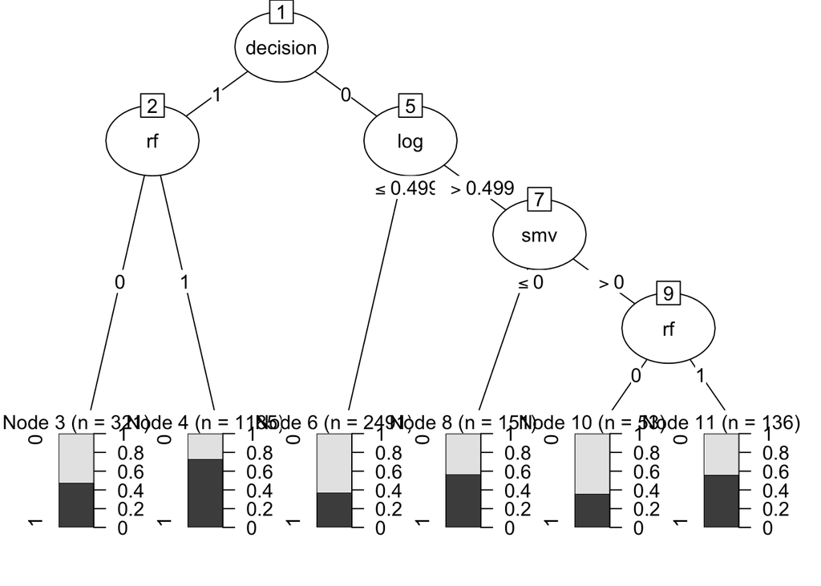

```r
plot(tree_model)
```

# 5 Evaluation of Model Statistics

Our model statistics yielded fairly similar results across the board, with an average accuracy score of 0.63 and Kappa value of 0.25. Our stacked decision tree produced slightly better results with regards to these two evaluative metrics, with a 0.65 accuracy and 0.28 Kappa. Though an accuracy level of 60% is not necessarily high in absolute terms, when considering this value in the context of NBA shots, field goal percentages for any given player typically never exceeds 50%; thus, our model’s accuracy exceeding the average make rate for players is indicative of model success.

# 6 R Shiny Application: NBA Shot Chart Explorer

## 6.1 Overview

The R Shiny application, titled “NBA Shot Chart Explorer,” serves as an interactive tool that augments our NBA Shot Prediction model. This application is designed to provide a user-friendly interface, enabling users to explore and visualize NBA shot data interactively. It offers insights into player performance, shot effectiveness, and game dynamics, crucial for strategic decision-making in basketball analytics.

## 6.2 Functionality and Usage

The application includes several interactive elements, such as dropdown menus, sliders, and buttons, which allow users to filter and analyze NBA shot data based on various parameters like player name, action type, game period, and shot distance.

### 6.2.1 Key Features

- **Player and Action Type Selection**: Users can select a specific player and the type of action (e.g., jump shot, layup) to analyze shots associated with those criteria.
- **Game Period and Shot Distance Filtering**: The app allows filtering shots by game periods and distance ranges, offering a nuanced look into shooting strategies at different game stages.
- **Shot Prediction**: Utilizing the predictive model developed, the app predicts the likelihood of a shot being successful based on user-defined parameters such as shot distance and court location.
- **Visual Shot Chart**: A dynamic shot chart rendered using `ggplot2` visually represents shots on the court, highlighting made and missed shots.

### 6.2.2 Importance

The app significantly enhances the usability of our NBA Shot Prediction model. It provides an interactive means to visualize complex shot data, making it more accessible for coaches, analysts, and basketball enthusiasts. The ability to predict shot outcomes and analyze shooting patterns can inform game strategies and player training programs.

## 6.3 How to Use the App

1. **Select Parameters**: Choose a player, action type, game period, and shot distance range.
2. **View Shot Chart**: Observe the distribution of shots on the court, color-coded by success.
3. **Make Predictions**: Adjust sliders to set specific shot conditions and use the ‘Predict’ button to get the model’s prediction for shot success.
4. **Analyze Data**: Use the visual and statistical output to analyze shooting trends and player performance.

## 6.4 Future Expansions

The application has significant potential for expansion and enhancement:

1. **Team Line-Up Integration**: Incorporating real-time data to display a team’s current line-up, allowing for scenario-based analysis of shot selection given the players on the court.
2. **Situation-Based Recommendation**: Expanding the model to recommend the best shot or player to take a shot in a given situation, considering factors like player fatigue, defensive setups, and historical performance under similar conditions.
3. **Enhanced Data Analytics**: Integrating more advanced statistical metrics and machine learning models to provide deeper insights into shooting efficiencies, player tendencies, and predictive analytics.
4. **User Customization**: Allowing users to create custom scenarios or input specific game situations to see tailored recommendations and predictions.
5. **Integration with Other Data Sources**: Including data from player tracking systems for more granular analysis, such as player movement patterns, spacing on the court, and defensive alignments.

# 7 R Shiny Dashboard

Because the HTML file is static for submission, we cannot integrate a working version of the Dashboard. However, below is an image of how it looks. You can access the Shiny Dashboard on the GitHub `https://github.com/mrrain02/TO414.git`

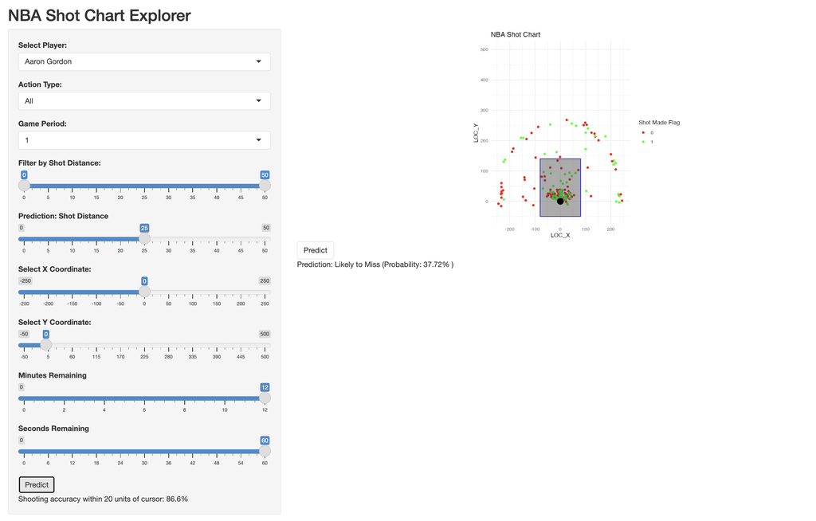

# 8 Conclusion

The NBA Shot Prediction Model will change the landscape of the National Basketball Association. Teams will be able to utilize this model to increase their chances of scoring, which will prove to be vital from both the financial and non-financial standpoint.

In particular, by leveraging our shot predictor model, NBA teams can capture what would otherwise be foregone revenue and bonuses from key missed shots. These opportunity costs can be massive for key missed shots. For instance, Jimmy Butler’s game-winning attempt and miss in the final seconds of the 2022 Eastern Conference Finals cost the Heat franchise upwards of $40-80M in lost Finals ticket revenue.

Non-financial impacts of key missed shots can be equally if not more devastating, as well. In recent years, the league has become less patient and tolerating of mistakes made by front office staff and players alike. Referring back to the Jimmy Butler example, despite an overall successful season, failing to secure a Finals berth resulted in the team letting go of key role players such as P.J. Tucker and Markieff Morris, as well as the team’s Basketball Analytics manager, Ruth Riley.

However, we understand that our product is not perfect – and we do acknowledge these limitations associated with using the model.

One limitation associated with using this model is that there may be sampling or historical biases in the training data, which can lead to inaccurate predictions. A way to mitigate this limitation is to regularly audit and update training data to ensure it remains representative of the current NBA landscape. Techniques such as data augmentation can ensure diversity in the data set. Another limitation is some factors influencing a player’s ability to make a shot (e.g., mental health, injuries, playing different position than usual) is not captured by the data.

The next steps in the process would be create a usable tool for a coach. In our presentation, we ran through an example calculation that our model created for the starting lineup of the Los Angeles Lakers. We took a hypothetical shot situations, ran the models we created, and output the player that would be most likely to make the shot. However, the method we used to do this was not scalable as we had to format our data and code in a specific way (i.e. reclean the data and reformat the data) so that it would run with the different models. Partially to blame for this is how the code is strucutred, and if we were to create functions insteead for the different processes, our model could be scalable for the situation described. Another next step is to use more historical data beyond the 2022 Season to make predictions. This could be very helpful for Veteran Players who have been in the league for many years.